# Predicting Insurance Costs

Author: Anil Kumar

### 1) Introduction

The purpose of this project is to see if insurance costs can be accurately predicted using demographic and health-related characteristics of policy holders. Being able to predict this information is important for insurance companies so that they can accurately plan a budget.

The dataset was obtained from: https://www.kaggle.com/mirichoi0218/insurance

### 2) Pre-processing and Cleaning

```r
# Include the necessary libraries
# (not all may be used...but I usually include the most common ones I use by habit)
library(tidyverse)
library(readxl)
library(jtools)
library(plotly)
library(caret)
library(pROC)
library(MLmetrics)
library(janitor)
library(lubridate)
library(priceR)
```

```r
#read in the data
data <- read.csv("insurance.csv")
data <- data %>% clean_names()
```

```r
#examine dataset
glimpse(data)
```

```
## Rows: 1,338
## Columns: 7
## $ age      <int> 19, 18, 28, 33, 32, 31, 46, 37, 37, 60, 25, 62, 23, 56, 27, 1~
## $ sex      <fct> female, male, male, male, male, female, female, female, male,~
## $ bmi      <dbl> 27.900, 33.770, 33.000, 22.705, 28.880, 25.740, 33.440, 27.74~
## $ children <int> 0, 1, 3, 0, 0, 0, 1, 3, 2, 0, 0, 0, 0, 0, 0, 1, 1, 0, 0, 0, 0~
## $ smoker   <fct> yes, no, no, no, no, no, no, no, no, no, no, yes, no, no, yes~
## $ region   <fct> southwest, southeast, southeast, northwest, northwest, southe~
## $ charges  <dbl> 16884.924, 1725.552, 4449.462, 21984.471, 3866.855, 3756.622,~
```

```r
#re-label the smoker columnn to "non-smoker"/"smoker" instead of "yes"/"no"
data <- data %>% mutate(smoker = factor(smoker, labels=c("non-smoker", "smoker")))
```

```r
#examine individual columns and count the number of missing values
summary(data)
```

```
##       age            sex           bmi           children            smoker
##  Min.   :18.00   female:662   Min.   :15.96   Min.   :0.000   non-smoker:1064
##  1st Qu.:27.00   male  :676   1st Qu.:26.30   1st Qu.:0.000   smoker    : 274
##  Median :39.00                Median :30.40   Median :1.000
##  Mean   :39.21                Mean   :30.66   Mean   :1.095
##  3rd Qu.:51.00                3rd Qu.:34.69   3rd Qu.:2.000
##  Max.   :64.00                Max.   :53.13   Max.   :5.000
##        region       charges
##  northeast:324   Min.   : 1122
##  northwest:325   1st Qu.: 4740
##  southeast:364   Median : 9382
##  southwest:325   Mean   :13270
##                  3rd Qu.:16640
##                  Max.   :63770
```

```r
sum(is.na(data))
```

```
## [1] 0
```

There are no missing values in the dataset and from the above summary it does not appear that there are any invalid entries. This makes life much easier as no major cleaning is necessary. The **children** column needs to be further explored as the range is 0-5. Depending on the counts for the possible numbers of children/dependents, the category levels may have to be collapsed if some are overly underrepresented.

```r
summary(factor(data$children))
```

```
##   0   1   2   3   4   5
## 574 324 240 157  25  18
```

It looks like there are few observations with 4 and 5 children. Therefore, the feature is collapsed into 4 categories: 0, 1, 2, and 3 or more children. The original column is then dropped.

```r
data <- data %>% mutate(num_children = factor(ifelse(children %in% c(3,4,5),"3 or more", children))) %>%
        select(-children)

summary(data$num_children)
```

```
##         0         1         2 3 or more
##       574       324       240       200
```

For reference, a summary of the data dictionary is below.

**FEATURES:**

- **age**: age of primary beneficiary
- **sex**: sex of primary beneficiary
- **bmi**: body mass index of primary beneficiary
- **num_children**: number of children/dependents covered by health insurance
- **smoker**: smoking status of primary beneficiary
- **region**: beneficiary’s residential area in the US

**TARGET:**

- **charges**: total medical costs of primary beneficiary and dependents

### 3) Exploratory Data Analysis

First, **charges** (the target variable) is explored. Afterward, each predictor is explored with respect to its relationship to **charges**.

```r
data$charges %>% summary()
```

```
##    Min. 1st Qu.  Median    Mean 3rd Qu.    Max.
##    1122    4740    9382   13270   16640   63770
```

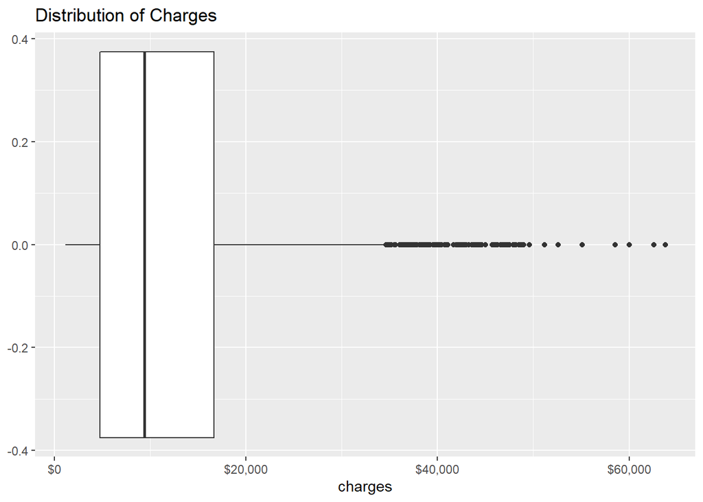

```r
ggplot(data, aes(charges)) + geom_boxplot() + scale_x_continuous(labels=scales::dollar_format()) +
       ggtitle("Distribution of Charges")
```

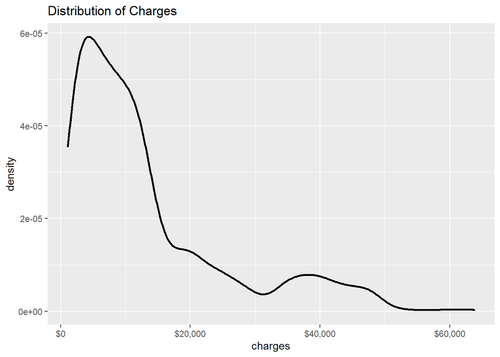

```r
  ggplot(data, aes(charges)) + geom_density(size=1) + scale_x_continuous(labels=scales::dollar_format()) +
       ggtitle("Distribution of Charges")
```

```r
data %>%  group_by(sex) %>%
                 summarize(n=n(),
                           percent=round(n()/nrow(.),2),
                           mean_charges = format_dollars(mean(charges, na.rm=TRUE),2),
                           median_charges=format_dollars(median(charges, na.rm=TRUE),2))
```

```
## # A tibble: 2 x 5
##   sex        n percent mean_charges median_charges
##   <fct>  <int>   <dbl> <chr>        <chr>
## 1 female   662    0.49 $12,569.58   $9,412.96
## 2 male     676    0.51 $13,956.75   $9,369.62
```

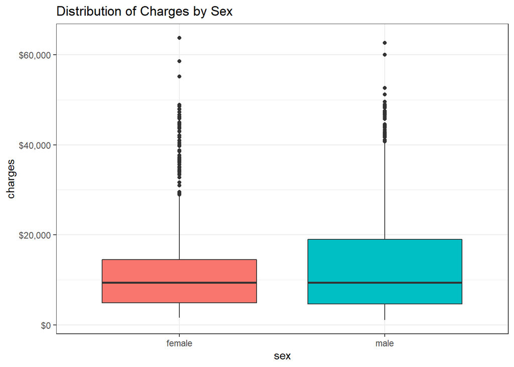

```r
data %>%  drop_na() %>%
          ggplot(.,aes(x=sex, y=charges, fill=sex)) +
          geom_boxplot() +
          ggtitle("Distribution of Charges by Sex") +
          scale_y_continuous(labels=scales::dollar_format()) +
          theme_bw() +
          theme(legend.position="none")
```

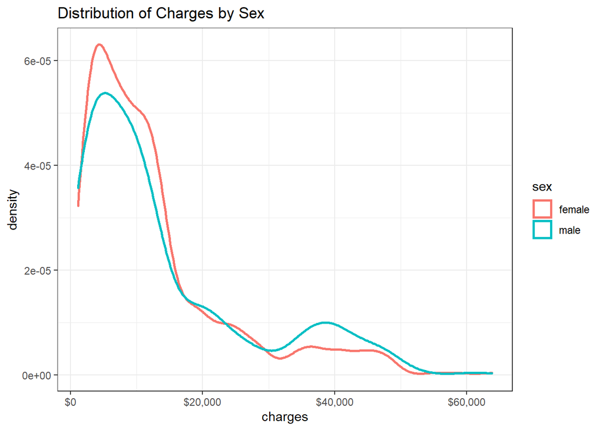

```r
data %>% drop_na() %>%
          ggplot(.,aes(x=charges, color=sex)) + geom_density(size=1) +
          ggtitle("Distribution of Charges by Sex") +
          scale_x_continuous(labels=scales::dollar_format()) +
          theme_bw()
```

```r
data %>%  group_by(smoker) %>%
                 summarize(n=n(),
                           percent=round(n()/nrow(.),2),
                           mean_charges = format_dollars(mean(charges, na.rm=TRUE),2),
                           median_charges = format_dollars(median(charges, na.rm=TRUE),2))
```

```
## # A tibble: 2 x 5
##   smoker         n percent mean_charges median_charges
##   <fct>      <int>   <dbl> <chr>        <chr>
## 1 non-smoker  1064     0.8 $8,434.27    $7,345.41
## 2 smoker       274     0.2 $32,050.23   $34,456.35
```

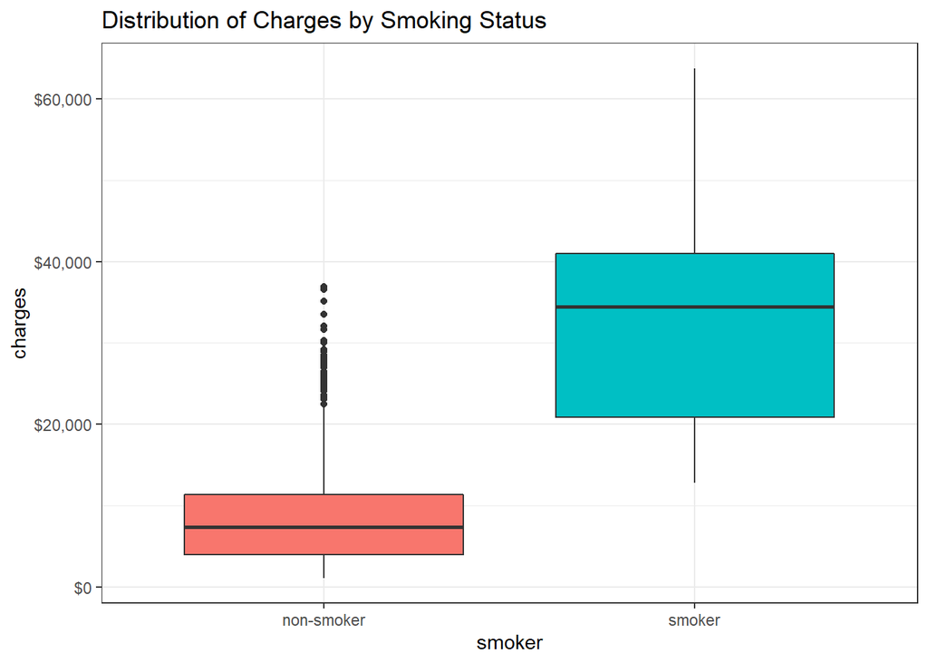

```r
data %>%  drop_na() %>%
          ggplot(.,aes(x=smoker, y=charges, fill=smoker)) +
          geom_boxplot() +
          ggtitle("Distribution of Charges by Smoking Status") +
          theme_bw() +
          scale_y_continuous(labels=scales::dollar_format()) +
          theme(legend.position="none")
```

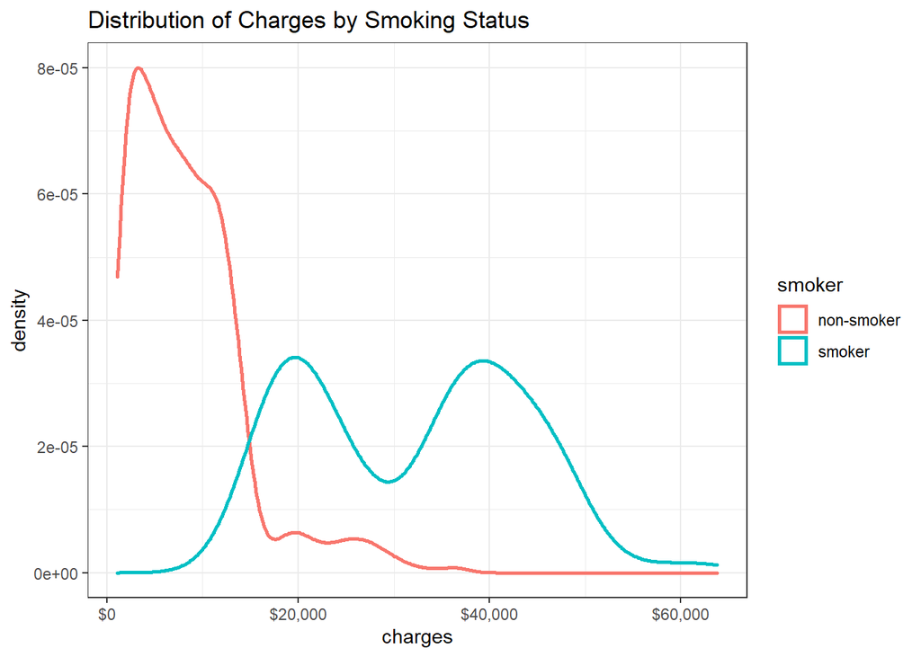

```r
data %>% drop_na() %>%
          ggplot(.,aes(x=charges, color=smoker)) + geom_density(size=1) +
          ggtitle("Distribution of Charges by Smoking Status") +
          scale_x_continuous(labels=scales::dollar_format()) +
          theme_bw()
```

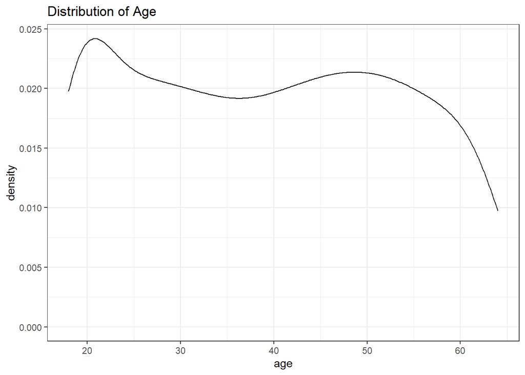

```r
data %>% drop_na() %>%
        ggplot(., aes(x=age)) +
               geom_density() +
               ggtitle("Distribution of Age") +
               theme_bw()
```

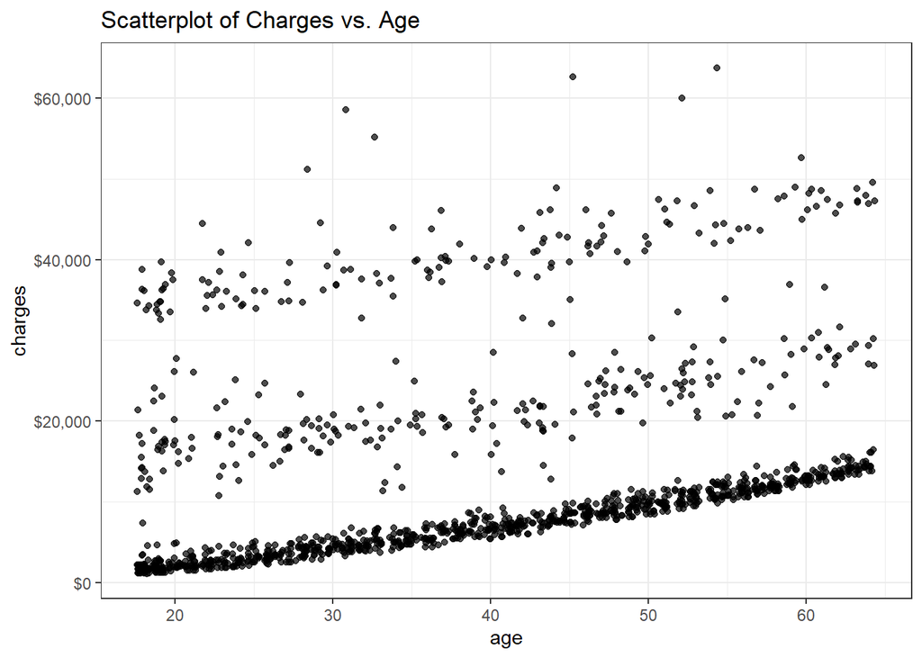

```r
data %>% drop_na() %>%
        ggplot(., aes(x=age,y=charges)) +
               geom_jitter(alpha=0.7) +
               ggtitle("Scatterplot of Charges vs. Age") +
               scale_y_continuous(labels=scales::dollar_format()) +
               theme_bw()
```

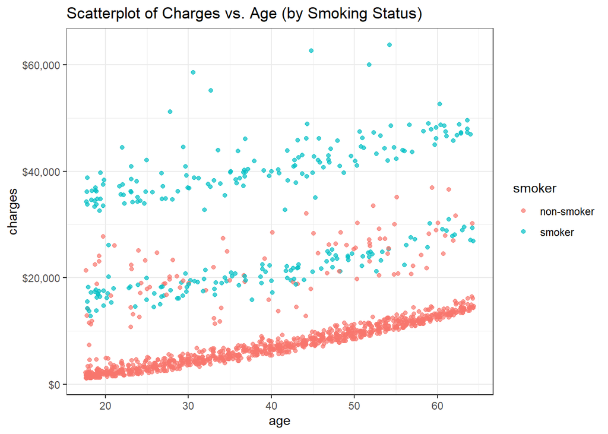

```r
data %>% drop_na() %>%
        ggplot(., aes(x=age,y=charges, color=smoker)) +
               geom_jitter(alpha=0.7) +
               ggtitle("Scatterplot of Charges vs. Age (by Smoking Status)") +
               scale_y_continuous(labels=scales::dollar_format()) +
               theme_bw()
```

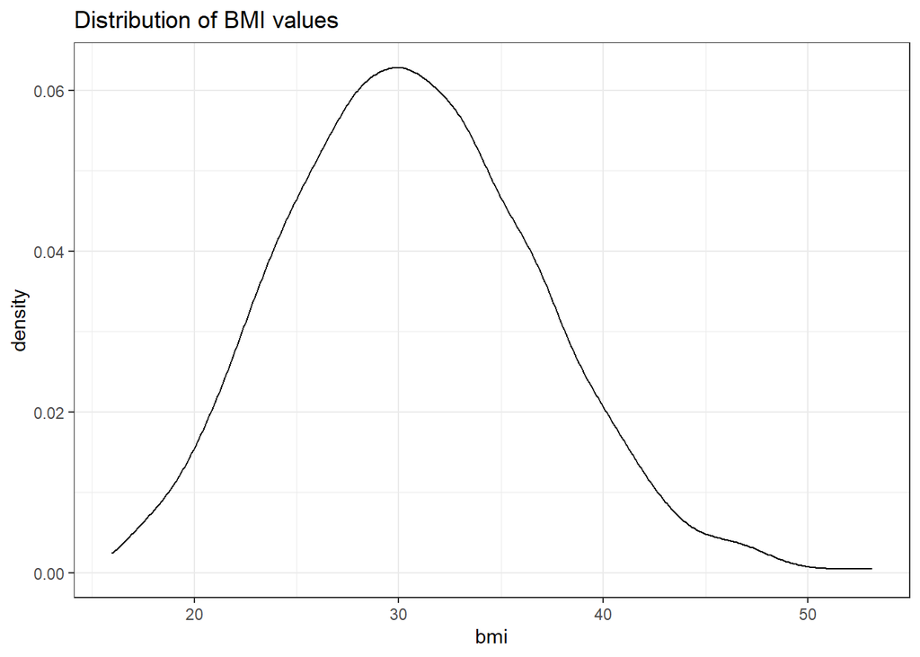

```r
data %>% drop_na() %>%
        ggplot(., aes(x=bmi)) +
               geom_density() +
               ggtitle("Distribution of BMI values") +
               theme_bw()
```

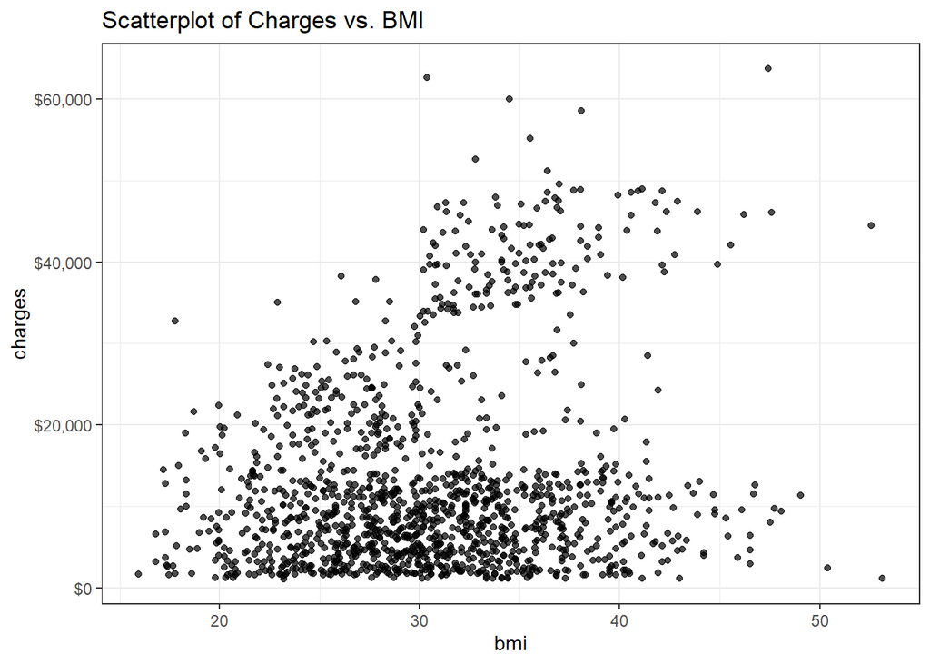

```r
data %>% drop_na() %>%
        ggplot(., aes(x=bmi,y=charges)) +
               geom_jitter(alpha=0.7) +
               ggtitle("Scatterplot of Charges vs. BMI") +
               scale_y_continuous(labels=scales::dollar_format()) +
               theme_bw()
```

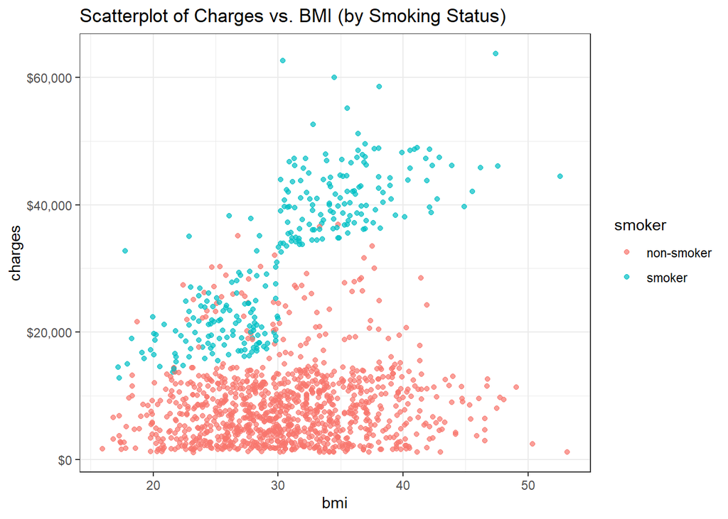

```r
data %>% drop_na() %>%
        ggplot(., aes(x=bmi,y=charges, color=smoker)) +
               geom_jitter(alpha=0.7) +
               ggtitle("Scatterplot of Charges vs. BMI (by Smoking Status)") +
               scale_y_continuous(labels=scales::dollar_format()) +
               theme_bw()
```

```r
data %>%  group_by(num_children) %>%
                 summarize(n=n(),
                           percent=round(n()/nrow(.),2),
                           mean_charges = format_dollars(mean(charges, na.rm=TRUE),2),
                           median_charges = format_dollars(median(charges, na.rm=TRUE),2))
```

```
## # A tibble: 4 x 5
##   num_children     n percent mean_charges median_charges
##   <fct>        <int>   <dbl> <chr>        <chr>
## 1 0              574    0.43 $12,365.98   $9,856.95
## 2 1              324    0.24 $12,731.17   $8,483.87
## 3 2              240    0.18 $15,073.56   $9,264.98
## 4 3 or more      200    0.15 $14,576.00   $10,483.79
```

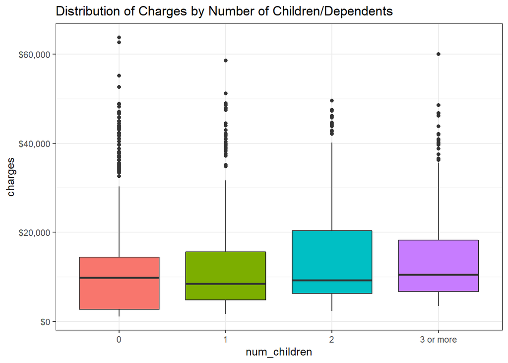

```r
data %>%  drop_na() %>%
          ggplot(.,aes(x=num_children, y=charges, fill=num_children)) +
          geom_boxplot() +
          ggtitle("Distribution of Charges by Number of Children/Dependents") +
          scale_y_continuous(labels=scales::dollar_format()) +
          theme_bw() +
          theme(legend.position="none")
```

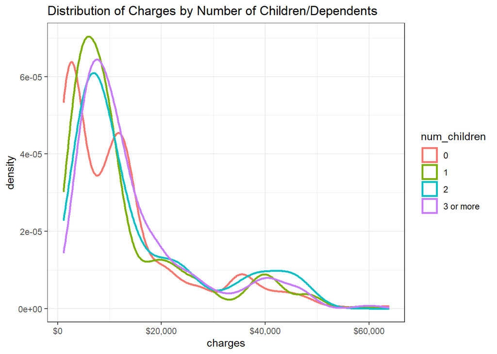

```r
data %>% drop_na() %>%
          ggplot(.,aes(x=charges, color=num_children)) + geom_density(size=1) +
          ggtitle("Distribution of Charges by Number of Children/Dependents") +
          scale_x_continuous(labels=scales::dollar_format()) +
          theme_bw()
```

```r
data %>%  group_by(region) %>%
                 summarize(n=n(),
                           percent=round(n()/nrow(.),2),
                           mean_charges = format_dollars(mean(charges, na.rm=TRUE),2),
                           median_charges = format_dollars(median(charges, na.rm=TRUE),2))
```

```
## # A tibble: 4 x 5
##   region        n percent mean_charges median_charges
##   <fct>     <int>   <dbl> <chr>        <chr>
## 1 northeast   324    0.24 $13,406.38   $10,057.65
## 2 northwest   325    0.24 $12,417.58   $8,965.80
## 3 southeast   364    0.27 $14,735.41   $9,294.13
## 4 southwest   325    0.24 $12,346.94   $8,798.59
```

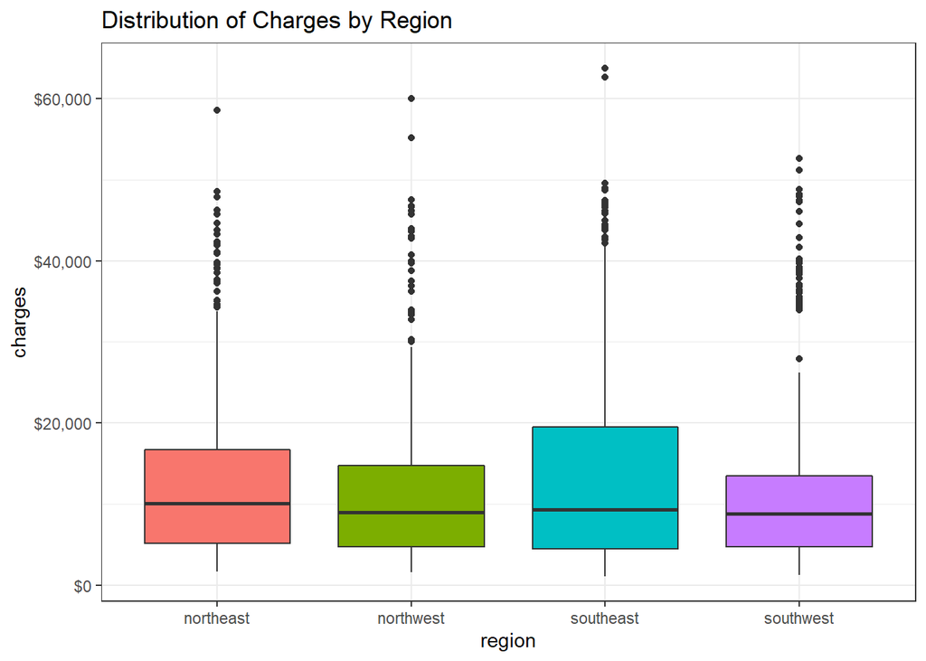

```r
data %>%  drop_na() %>%
          ggplot(.,aes(x=region, y=charges, fill=region)) +
          geom_boxplot() +
          ggtitle("Distribution of Charges by Region") +
          scale_y_continuous(labels=scales::dollar_format()) +
          theme_bw() +
          theme(legend.position="none")
```

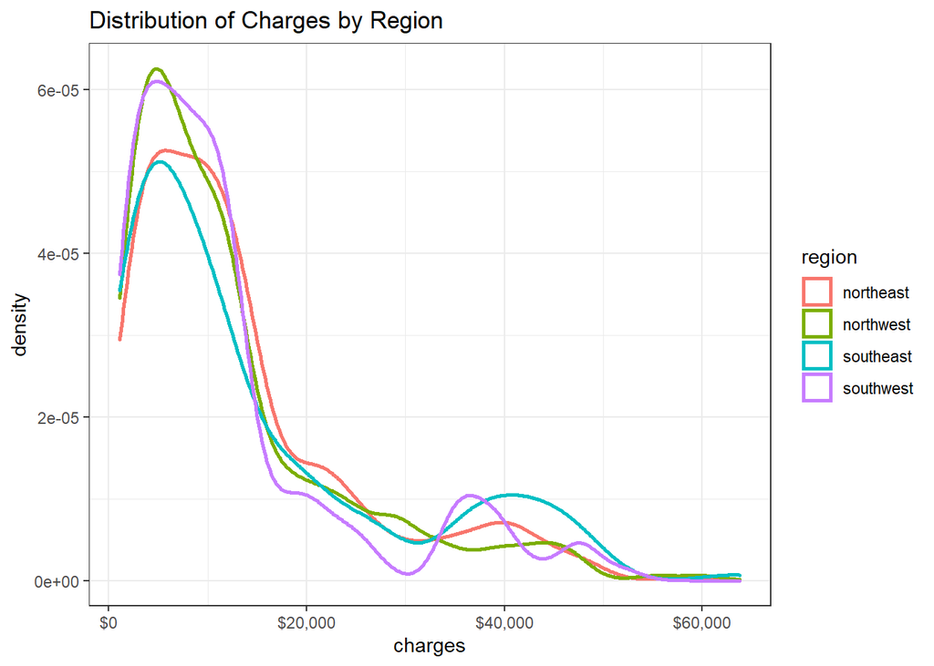

```r
data %>% drop_na() %>%
          ggplot(.,aes(x=charges, color=region)) + geom_density(size=1) +
          ggtitle("Distribution of Charges by Region") +
          scale_x_continuous(labels=scales::dollar_format()) +
          theme_bw()
```

Some obvious trends from the above visualizations:

- **Smoking** status plays a major role in costs
- There is a visually apparent interaction between **smoking** and **bmi**; that is, **charges** increases as **bmi** increases, but at higher rate for **smokers** compared to **non-smokers**

### 4) Modeling and Predicting Charges

In order to budget properly, an insurance company needs to be able to accurately predict costs. Let’s see how accurately this can be accomplished for this dataset. Before any modeling is completed, the correlation coefficient of the continuous predictors (**bmi** and **age**) is checked. With a low value of 0.11, both predictors can be included in the model without concern of multicollinearity.

```r
data %>% select(bmi, age) %>% cor()
```

```
##           bmi       age
## bmi 1.0000000 0.1092719
## age 0.1092719 1.0000000
```

Let’s start with some diagnostic linear regression models. The first model uses all of the predictors, and the second one uses all of the predictors plus an interaction term between **bmi/smoker**.

```r
model <- lm(charges ~ ., data=data)
summ(model, digits=3, confint = TRUE)
```

| Observations | 1338 |
| --- | --- |
| Dependent variable | charges |
| Type | OLS linear regression |

| F(10,1327) | 401.310 |
| --- | --- |
| R² | 0.752 |
| Adj. R² | 0.750 |

|  | Est. | 2.5% | 97.5% | t val. | p |
| --- | --- | --- | --- | --- | --- |
| (Intercept) | -11929.103 | -13876.876 | -9981.331 | -12.015 | 0.000 |
| age | 256.762 | 233.414 | 280.110 | 21.574 | 0.000 |
| sexmale | -121.129 | -774.024 | 531.766 | -0.364 | 0.716 |
| bmi | 337.755 | 281.658 | 393.853 | 11.812 | 0.000 |
| smokersmoker | 23811.978 | 23001.272 | 24622.685 | 57.620 | 0.000 |
| regionnorthwest | -391.070 | -1325.663 | 543.523 | -0.821 | 0.412 |
| regionsoutheast | -1043.891 | -1983.146 | -104.637 | -2.180 | 0.029 |
| regionsouthwest | -954.819 | -1891.889 | -17.749 | -1.999 | 0.046 |
| num_children1 | 391.141 | -435.541 | 1217.823 | 0.928 | 0.353 |
| num_children2 | 1637.004 | 721.416 | 2552.593 | 3.507 | 0.000 |
| num_children3 or more | 1226.892 | 248.364 | 2205.420 | 2.460 | 0.014 |

Standard errors: OLS

```r
model <- lm(charges ~ . + bmi:smoker, data=data)
summ(model, digits=3, confint = TRUE)
```

| Observations | 1338 |
| --- | --- |
| Dependent variable | charges |
| Type | OLS linear regression |

| F(11,1326) | 638.255 |
| --- | --- |
| R² | 0.841 |
| Adj. R² | 0.840 |

|  | Est. | 2.5% | 97.5% | t val. | p |
| --- | --- | --- | --- | --- | --- |
| (Intercept) | -2186.519 | -3893.989 | -479.048 | -2.512 | 0.012 |
| age | 263.515 | 244.833 | 282.196 | 27.672 | 0.000 |
| sexmale | -488.776 | -1011.667 | 34.115 | -1.834 | 0.067 |
| bmi | 22.840 | -27.394 | 73.074 | 0.892 | 0.373 |
| smokersmoker | -20368.034 | -23602.351 | -17133.716 | -12.354 | 0.000 |
| regionnorthwest | -616.781 | -1364.501 | 130.939 | -1.618 | 0.106 |
| regionsoutheast | -1211.057 | -1962.427 | -459.688 | -3.162 | 0.002 |
| regionsouthwest | -1221.051 | -1970.820 | -471.281 | -3.195 | 0.001 |
| num_children1 | 324.199 | -337.050 | 985.447 | 0.962 | 0.336 |
| num_children2 | 1531.746 | 799.364 | 2264.129 | 4.103 | 0.000 |
| num_children3 or more | 1389.619 | 606.845 | 2172.393 | 3.483 | 0.001 |
| bmi:smokersmoker | 1440.366 | 1337.061 | 1543.671 | 27.352 | 0.000 |

Standard errors: OLS

The model with the interaction term has a better fit with an Adjusted R<sup>2</sup> of 0.84 compared to 0.75 for the simpler model.

Now, to see if predictions can be accurately made. First, training and validation datasets are created. The training set consists of 70% of the data and the validation set consists of 30% of the data. A partition is created so that both the training and validation sets have an equal proportion of observations where charges are above or below the median charge from the original dataset.

```r
set.seed(2)

median_charge = median(data$charges)
temp <- data %>% mutate(charges_partition = factor(ifelse(charges<=median_charge,
                                                          "<= Median", ">Median")))

index = createDataPartition(temp$charges_partition, p = 0.70, list = FALSE)
data_train = temp[index, ]
data_val = temp[-index, ]

data_train <- data_train %>% select(-charges_partition)
data_val <- data_val %>% select(-charges_partition)
```

Next, to check that the split was made appropriately.

```r
cat("Mean Charges Training Set:", format_dollars(mean(data_train$charges),2),
    "\nMean Charges Validation Set:", format_dollars(mean(data_val$charges),2),
    "\n\nMedian Charges Training Set:", format_dollars(median(data_train$charges),2),
    "\nMedian Charges Validation Set:", format_dollars(median(data_val$charges),2))
```

```
## Mean Charges Training Set: $13,219.16
## Mean Charges Validation Set: $13,390.64
##
## Median Charges Training Set: $9,394.45
## Median Charges Validation Set: $9,290.00
```

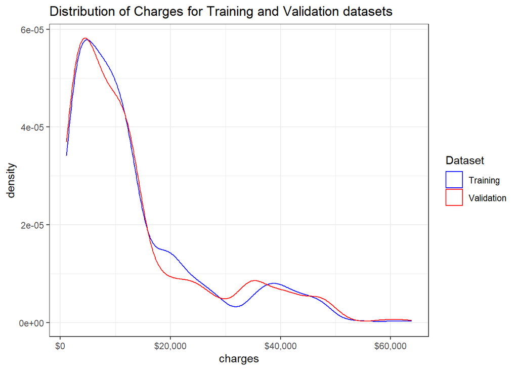

```r
ggplot(data_train) + geom_density(data=data_train, aes(x=charges, col='blue')) +
                     geom_density(data=data_val, aes(x=charges, col='red')) +
                     theme_bw() +
                     scale_color_manual(labels = c("Training", "Validation"), values = c("blue", "red")) +
                     guides(color=guide_legend("Dataset")) +
                     ggtitle("Distribution of Charges for Training and Validation datasets") +
                     scale_x_continuous(labels=scales::dollar_format())
```

Based on the similar overlying density plots and similar mean/median charges for both of the datasets, an appropriate split was completed.

Now, the linear regression model with the interaction term is utilized using the training set and 5-fold cross validation is implemented to assess the effectiveness of the model and its ability of to predict new data prior to using it with the validation set.

```r
set.seed(1234)

train_control <- trainControl(method = "cv", number = 5, p=0.70)

model <- train(charges ~ . + bmi:smoker, data = data_train, method = "lm", trControl = train_control)

print(model)
```

```
## Linear Regression
##
## 938 samples
##   6 predictor
##
## No pre-processing
## Resampling: Cross-Validated (5 fold)
## Summary of sample sizes: 751, 750, 750, 751, 750
## Resampling results:
##
##   RMSE      Rsquared   MAE
##   4942.522  0.8249685  3060.109
##
## Tuning parameter 'intercept' was held constant at a value of TRUE
```

The model is then utilized to predict charges for both the training and validation sets. The **mean absolute error (MAE)** and **Root Mean Squared Error (RMSE)** for predicted charges is calculated for both datasets.

```r
preds = predict(model, newdata=data_train)

cat("MAE (Training Set):", format_dollars(MAE(preds,data_train$charges),2),
    "\nRMSE (Training Set):", format_dollars(RMSE(preds,data_train$charges),2))
```

```
## MAE (Training Set): $3,025.20
## RMSE (Training Set): $4,893.92
```

```r
preds = predict(model, newdata=data_val)

cat("\nMAE (Validation Set):", format_dollars(RMSE(preds,data_val$charges),2),
    "\nRMSE (Validation Set):", format_dollars(RMSE(preds,data_val$charges),2))
```

```
##
## MAE (Validation Set): $4,712.22
## RMSE (Validation Set): $4,712.22
```

The fact that the MAE/RMSE for the validation set is not too far off from the MAE/RMSE of the training set supports the idea that the model did not overfit on the training data.

Next, scatterplots of *Actual Charges vs. Predicted Charges* are made for the validation set. The second plot is faceted by smoking status.

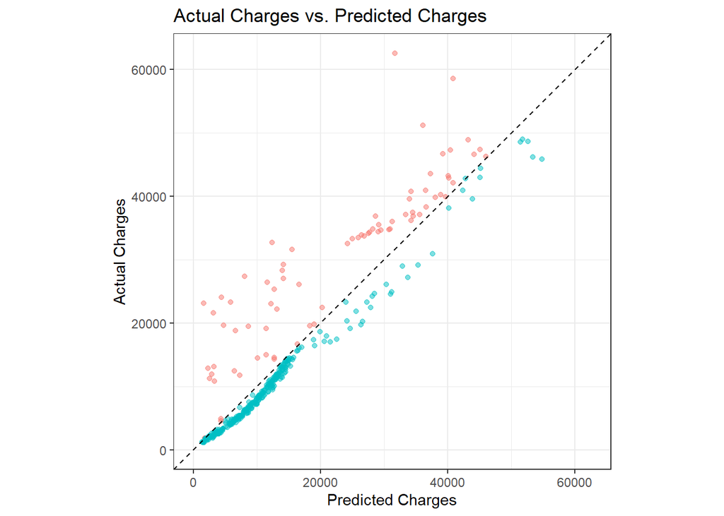

```r
df_pred <- data_val %>%
                 mutate(Predicted_Charges=preds) %>%
                 rename(Actual_Charges=charges) %>%
                 mutate(Actual_Charges_Under_Prediction = ifelse(Actual_Charges < Predicted_Charges,"Yes","No"))

df_pred %>% ggplot(., aes(x=Predicted_Charges, y=Actual_Charges,
                          color=Actual_Charges_Under_Prediction)) +
                        geom_jitter(alpha=0.5) +
                        geom_abline(intercept = 0, slope=1,
                                    linetype="dashed", size=0.5) +
                        coord_fixed(ratio=1, xlim=c(0, max(df_pred$Actual_Charges)),
                                    ylim=c(0, max(df_pred$Actual_Charges))) +
                        theme_bw() +
                        labs(x="Predicted Charges", y="Actual Charges") +
                        ggtitle("Actual Charges vs. Predicted Charges") +
                        theme(legend.position="none")
```

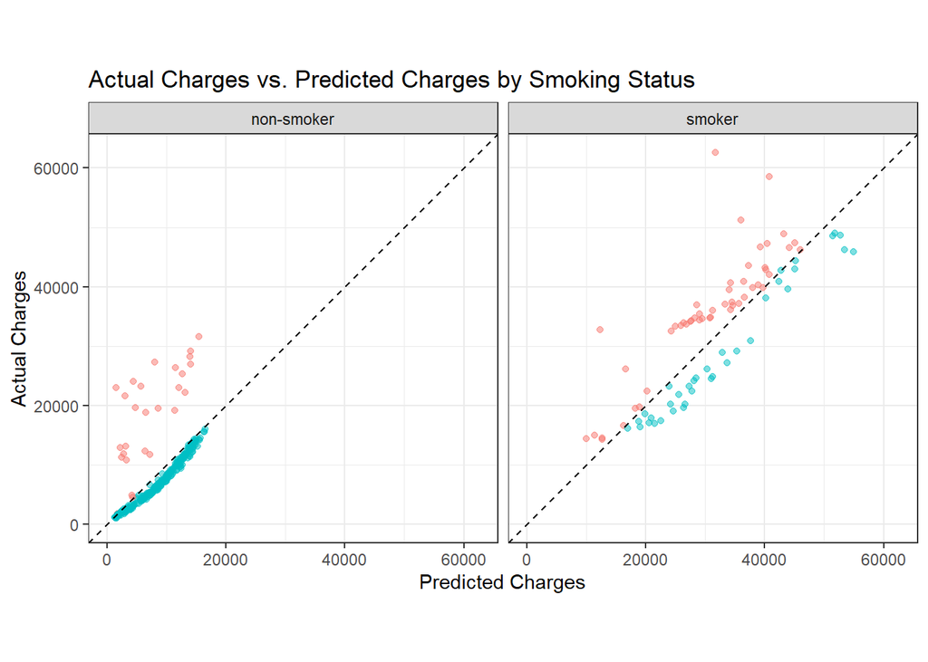

```r
df_pred %>% ggplot(., aes(x=Predicted_Charges, y=Actual_Charges,
                          color=Actual_Charges_Under_Prediction)) +
                        geom_jitter(alpha=0.5) +
                        geom_abline(intercept = 0, slope=1,
                                    linetype="dashed", size=0.5) +
                        coord_fixed(ratio=1, xlim=c(0, max(df_pred$Actual_Charges)),
                                    ylim=c(0, max(df_pred$Actual_Charges))) +
                        theme_bw() +
                        labs(x="Predicted Charges", y="Actual Charges") +
                        ggtitle("Actual Charges vs. Predicted Charges by Smoking Status") +
                        facet_grid(cols=vars(smoker)) +
                        theme(legend.position="none")
```

For the most part the predicted charges align closely with the actual charges. The blue points represent observations where the actual charges were less than the predicted charges, and the red points represent observations where actual charges were greater than or equal to predicted charges. From the scatterplot it is difficult to ascertain the number of points that fall into these two categories. Below, a breakdown is shown.

```r
df_pred %>%  group_by(Actual_Charges_Under_Prediction) %>%
                 summarize(n=n(),
                           percent=round(n()/nrow(.),2))
```

```
## # A tibble: 2 x 3
##   Actual_Charges_Under_Prediction     n percent
##   <chr>                           <int>   <dbl>
## 1 No                                 77    0.19
## 2 Yes                               323    0.81
```

Out of the 400 observations in the validation set, for 323 (81%) observations the actual charges were less than the predicted charges. With respect to budgeting, it’s definitely better for the company to end up paying less than a patient’s planned budget than over it. However, in the end, looking at the percentage of individual patient budgets that were exceeded or not does not give a summary of the big picture. An insurance company would need to know the cumulative total charges from all of the patients to see if the overall budget was planned appropriately. Calculations for this scenario in both the training and validation sets are below.

```r
preds = predict(model, newdata=data_train)

temp <- data_train %>% select(charges) %>%
               rename(Actual_Charges=charges) %>%
               mutate(Predicted_Charges = round(preds,2)) %>%
               mutate(error=Actual_Charges-Predicted_Charges)

cat("Number of Observations: ", nrow(data_train),
    "\nTotal Predicted Charges (Training set): ", format_dollars(sum(temp$Predicted_Charges),2),
    "\nTotal Actual Charges (Training set): ", format_dollars(sum(temp$Actual_Charges),2),
    "\nDifference (Training set): ", format_dollars(sum(temp$Predicted_Charges)-sum(temp$Actual_Charges),2))
```

```
## Number of Observations:  938
## Total Predicted Charges (Training set):  $12,399,570.96
## Total Actual Charges (Training set):  $12,399,570.86
## Difference (Training set):  $0.10
```

```r
preds = predict(model, newdata=data_val)

temp <- data_val %>% select(charges) %>%
               rename(Actual_Charges=charges) %>%
               mutate(Predicted_Charges = round(preds,2)) %>%
               mutate(error=Actual_Charges-Predicted_Charges)

cat("\n\nNumber of Observations: ", nrow(data_train),
    "\nTotal Predicted Charges (Training set): ", format_dollars(sum(temp$Predicted_Charges),2),
    "\nTotal Actual Charges (Training set): ", format_dollars(sum(temp$Actual_Charges),2),
    "\nDifference (Training set): ", format_dollars(sum(temp$Predicted_Charges)-sum(temp$Actual_Charges),2))
```

```
##
##
## Number of Observations:  938
## Total Predicted Charges (Training set):  $5,346,432.22
## Total Actual Charges (Training set):  $5,356,254.13
## Difference (Training set):  $-9,821.91
```

For the 938 observations in the training set, the total predicted charges was $0.10 more than the actual charges. However, the model trained on this data so this does not tell us if the model can be appropriately utilized on new data.

For the 400 observations in the validation set, the total predicted charges was $9,821.91 less than the actual charges (i.e. total actual charges were slightly over the predicted budget). This is quite good considering the total predicted budget was $5,346,432.22. The $9,821.91 difference equates to a 0.18% absolute percentage error.

## 5) Conclusions

The model was able to predict the budget in the validation set with a 0.18% absolute percentage error, which indicates that it could be a useful tool to use for budget planning purposes. More data is needed to validate the model’s accuracy and predictive power.

Thanks for reading and feel free to email me with questions or comments.